# City of Heroes Arena PvP Demo Analysis

Code and Tutorial created by @Silent Method, July 2020

### Introduction

In order to pull some basic stats from 8v8 Arena matches (and save myself a ton of time trying to do the same in VOD reviews... and be a huge nerd), in early July 2020 I wrote code in R to parse the output of .cohdemo files. The code posted here can be run in R, which is downloadable for free at https://cran.r-project.org/bin/windows/base/ (Windows link), though you may also want RStudio (https://rstudio.com/products/rstudio/download/) if you plan to do any editing.

### Brief Patch Notes

- 11/5/20 - very minor updates. The code has been running without issues for quite some time, but it has been in maintenance mode mostly due to lack of free time on my part. I will generally be on hiatus for a while, so I may be slow to respond to future queries on Discord. While parsing demo code is generally straightforward, there are a lot of directions one can go to spruce up the output (e.g. into reports or dashboards), and I will not have the time to develop a process for that. xhiggy has done a lot of awesome work in that vein for his parsing code; consider reaching out to him if you are interested in a Python / Google Data Studio approach. In the meantime, I'll continue to leave the existing code and tutorials here on GitHub. Enjoy!
- 10/1/20 - overdue update - added a few powers, along with a bug fix or two for entity detection. The pre-evasion window has been shortened to one second before the first attack (fewer false positives), while the default spike window (to count contiguous attacks as part of one spike) has been adjusted to 3.7 sec instead of 3.5 sec. Raptor/Fly has been removed as an "evasion" -- players must take at least one additional action beyond simply toggling on Fly to count as an active evasion, and this is controlled via a new parameter removeFlyEvasion -- but is still tracked as a defensive power. There is also a new parameter, dropNPCentity, which defaults to FALSE but can be set to TRUE in extremely rare cases where entity detection is failing because it's picking up pets. There have also been several more customized functions created for analysis, though those would take longer to document, so they haven't yet been added to the public release.
- 8/20/20 - added a few powers. Added a "knockbacks" output to the primary output which displays very simply the times that players got knocked back (if any). Modified pre-evasion credit default to -1.5 to +1 second window instead of -2 to +1.
- 8/18/20 - added a few powers. Also added a bug fix for rare situations where unmatched double quotes could mess up the initial read of the demo file (appears to work in practice). A new parameter returnRawDF was added, default FALSE, and is documented below - mostly for advanced users. The main output now includes a deathTable which should be more accurate due to a slightly expanded death de-duplication window. Finally, a progress meter has been added for the longest runtime portion of the code, which I am still too lazy to fully vectorize but should run quite quickly.
- 8/13/20 - added a few powers.
- 8/11/20 - minor tweak to the analysis of healing functions - "on_heal_pct" stat now excludes spikes where the person in question was the target (e.g. emps cannot Heal Other / Absorb Pain themselves, so they shouldn't see on_heal_pct rates suffer when they are the target).
- 8/10/20 - added analysis of green inspirations, "smart" start and end of match detection (on by default), a few more outputs like map name and duration of ability tracking (should be 10 minutes 1 second by default with smart start and end of match detection), abs_timing_distance as an offensive statistic. Search for 8/10 in the rest of this document in order to see some notes that I integrated on these features.
- 8/4/20 - revamped entity detection (which was the oldest, laziest part of the code) so that the demo should work fairly well for participant and spectator demos alike. This means the exclNames parameter is likely obsolete. Also revamped team assignment based on something suggested in xhiggy and mjb's code - thank you! Finally, I added customStart as an optional parameter, with similar functionality to customEnd.

### Why use this?

City of Heroes offers virtually no Arena statistics other than kill counts (which tend to mean very little, especially from a single match). Parsing chat logs can be done by individual players to see their exact damage output - fun note, you can use damage badge progress for a shortcut - but that's time-consuming, individualized, and raw damage output isn't all that important by itself either.

This code uses some built-in assumptions to try to identify spikes in a typical Arena match and figure out who used which powers, at what time, including both the offensive and defensive (evasion/healing) side of things. This can be useful in determining areas to improve as well as figuring out why a match occurred the way that it did.

In the past few weeks of testing and using this code, Renegades players have used it on a voluntary basis for their own knowledge and improvement. Now, in releasing it more broadly, people are free to do with it as they please. With that said, in a small PvP community that exists only as long as we are able to find people willing to play against each other, using match statistics to beat people over the head - teammates or opponents - probably isn't the best use of anyone's time. *Everyone* I've played with / against has had good and bad matches, both offensively and defensively, so keep that in mind as well.

Many of the metrics provided by this code start to make more sense after reviewing not one, but several matches - good ones, bad ones - and getting a sense for how they look when things work out well vs. when they don't.

Finally, users may edit this code and improve on it, or they may develop their own, as a few others started working on in July. Use whatever works best for you. My goal in providing this publicly is to give a user-friendly tutorial for one option that has worked well over the last several weeks.

Note that in reviewing CoH demo output, there are two parts: the code that is used to process the demo output into functional data tables, and the (optional) code that is used to process that output further into visualizations (e.g. color-coded reports, interactive dashboards). This code runs the first part well but is not intended to convert the tabular output -- including the raw data frame of all FX, targets, and timing, which is exported by this code -- into a fully visualized product. Interested users can pick up where this code leaves off via R Markdown, R Shiny, Google Data Studio, etc.

### Why would I need to edit the code?

Mostly because it's incomplete. I've built it to handle many situations, but for example, I:

...so you could easily need to add to it. However, in most situations, this only consists of modifying some of the default parameters - you can add powers or change the number of expected players this way - rather than needing to edit the code.

### What if I have a question about the meaning of the output, or I run into an issue I can't fix?

Message me on the Homecoming PvP Discord: @Silent Method

Other players in the community may make improvements to the code over time, or I may periodically release updated versions with some of my own fixes.

### How do I use it?

- Download the two .R code files if you haven't done so already
- Load into an Arena match
- Type "/demorecord DEMONAME" into chat (a lot of times I will use d1, d2, d3 for the first matches of the night and then rename them later)
- Play (or spectate) the match
- Optionally, at the buzzer at the end of the match, type or hit a macro for /demostop . Otherwise the demo will stop when you leave the zone, but it may pick up kills that occur after the buzzer. Note that smart start and end detection is on by default, so scores should be pretty close to accurate, even if you recorded time after the buzzer
- Open R or RStudio
- **If you are in R**, you will probably want to open a new script (File -> New Script) so that you can copy some of the code below and then run highlighted portions (highlight -> Ctrl+R), where the output will appear in the console (stretch the console window as needed).
- **If you are in RStudio**, which requires you to also have R installed, then you should already have a script and console window. Some versions of RStudio use Ctrl+Enter to run highlighted parts instead of Ctrl+R.
- Run a few bits of code in R / RStudio (minimalist example below) and inspect the output:

```r
## Not run
source("C:/FOLDER1/FOLDER2/coh_parseDemo.R")        ## Fill in the location where you put coh_parseDemo.R
source("C:/FOLDER1/FOLDER2/coh_analyzeFunctions.R") ## Fill in the location where you put coh_analyzeFunctions.R

## Note that if you modify either of the above files and save them, you will need to source them again (i.e. run the
##   above lines of code) in order for the changes to take effect. This is particularly true when you need to remove an
##   entity by modifying the exclNames parameter.

setwd("C:/Homecoming/CoH/client_demos")             ## Fill in the location of your City of Heroes installation -> demo folder
demoname<-"d1"                                      ## Fill in the name of the demo you recorded
out1 <- parseDemo(demoname, checkEntities = TRUE)   ## This stores the results in the "out1" object

## Note that in the parseDemo function above, you can modify many of the other default parameters, which are covered later on.

out1$spikeComparison                                ## Quick high-level match summary
out1$emoteUsage                                     ## For checking emote usage

## The next few functions produce useful summary output for Team 0 (ally team) and Team 1 (enemy team)

offense0<-analyzeGroupOffense(out1,0)               ## Offensive summary for Team 0
offense1<-analyzeGroupOffense(out1,1)               ## Offensive summary for Team 1

defense0<-analyzeGroupDefense(out1,0)               ## Defensive summary for Team 0
defense1<-analyzeGroupDefense(out1,1)               ## Defensive summary for Team 1

healing0<-analyzeGroupHealing(out1,0)               ## Healing summary for Team 0
healing1<-analyzeGroupHealing(out1,1)               ## Healing summary for Team 1

greens0<-analyzeGroupGreens(out1, 0, greenMax=20)   ## Green insp summary for Team 0 (added 8/10)
greens1<-analyzeGroupGreens(out1, 1, greenMax=20)   ## Green insp summary for Team 1 (added 8/10)

## Now, in the console, you can simply call objects like offense0 to see the summaries.
## However, out1 has more data than just these summaries. You can run names(out1) to inspect further.
```

### What if I want to kick the output out to Excel?

That can easily be done via write.csv (or export from the rio package, which would need to be installed, etc.). Any table of output can be written to a .csv file, possibly modifying it first. An example is below, though I have tended to use this code more for review of specific matches rather than for aggregating data across matches, as team comps, attack chains, etc. tend to shift over time.

```r
## Example output to .csv (not run)
## The file will be output to your current working directory - getwd().
## Users can easily write a loop to throw different outputs into different filenames, following the example here:
demoname <- "072220_4"
out1 <- parseDemo(demoname, checkEntities = TRUE)

teamIndex <- 0
write.csv(analyzeGroupOffense(out1,teamIndex), paste0("offenseData_", demoname, "_team_", teamIndex, ".csv"),
         row.names=FALSE, na="")
teamIndex <- 1
write.csv(analyzeGroupOffense(out1,teamIndex), paste0("offenseData_", demoname, "_team_", teamIndex, ".csv"),
         row.names=FALSE, na="")
## ...etc. Users may instead want to output an entire scrim night's worth of data; see the bottom of the Example below
##    for code to rbind multiple matches' results.
```

### A quick note on Entities, which you will be prompted to check if you leave checkEntities = TRUE

If you run the code exactly as shown above, you'll be prompted to check entities. Demos identify entities as players, pets, and so forth. Here is an example from a recent match, and you can see that it makes its best guess about team membership, which should usually be correct:

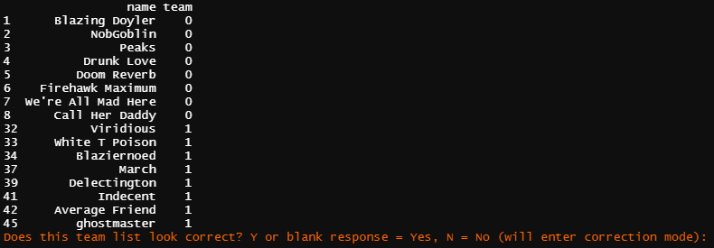

Follow the prompts to either confirm the list or enter editing mode, where you can declare each entity to be a player (or not) and assign them to a team. If you don't have exactly *expectedPlayers* number of players after this point, the code will error out. *expectedPlayers* is a parameter - covered later on - indicating how many players to expect in the match. By default, it is 16, which covers 8v8s. You should be able to modify it without issues, but it has not been tested extensively outside of 8v8s.

# Example

The example below contains some notes explaining how I've defined parts of the output.

This whole process isn't perfect, but it does contain some useful information, especially when viewed over the span of several matches. This particular match is from 7/22, Renegades vs. Rare on Striga.

```r
out1 <- parseDemo("072220_4",checkEntities = TRUE)
## NOTE: I recommend running the code in R or RStudio, not in Jupyter, because the list won't show before the prompt.
```

```
Does this team list look correct? Y or blank response = Yes, N = No (will enter correction mode): Y
                 name team
1      Blazing Doyler    0
2           NobGoblin    0
3               Peaks    0
4          Drunk Love    0
5         Doom Reverb    0
6    Firehawk Maximum    0
7  We're All Mad Here    0
8      Call Her Daddy    0
32          Viridious    1
33     White T Poison    1
34        Blaziernoed    1
37              March    1
39       Delectington    1
41           Indecent    1
42     Average Friend    1
45        ghostmaster    1
```

```
Entity check complete. Proceeding...
```

#### The spike comparison contains a basic summary showing:

- Map (added 8/10)
- Runtime of the demo's tracking portion - should typically be 10 minutes, 1 second if using smartStart and smartEnd
- Approximate score of the match (not perfect but probably correct 95% of the time; once in a while, deaths get missed, and kills after the buzzer will count unless you use the *customEnd* parameter. Using /demostop at the buzzer will improve accuracy)
- Approximate number of spikes fired (can tune spike detection with parameters)
- Average number of players who fired at least one attack per spike
- Average number of total attacks fired per spike
- Average time (in seconds) between the first activated power on spike and the last one (does not count animation time), i.e. the duration of firing
- Average "timing difference" (larger values = players' first attacks on spike were more spaced out, which is bad. This metric will be explained later)

```r
out1$spikeComparison                                ## Quick high-level match summary
```

**$map**

'Striga Isle'

**$runtime**

'10:01'

**$spikeComparison**

| Spike_Attribute | Ally | Enemy |
| --- | --- | --- |
| Approx Kills | 16.000000 | 16.000000 |
| Total Spikes | 52.000000 | 50.000000 |
| Avg Players on Spike | 3.788462 | 4.240000 |
| Avg Attacks Per Spike | 7.923077 | 8.180000 |
| Avg Spike Duration | 4.040365 | 3.809140 |
| Avg Timing Diff | 1.002010 | 1.018158 |

#### This code checks for any emote usage. Sometimes I use /em holdtorch (which is not an animation canceling emote) at the start of the match just to confirm that it's working, but otherwise there should generally be no emote usage:

```r
out1$emoteUsage                                     ## For checking emote usage
```

'No emote usage'

### Offensive summaries

- targeted = approximate number of times targeted. This is **incredibly important context** for pretty much everything else in the output. For example, someone who gets targeted 20 times *probably should not* be on much more than 50-60% of spikes at the absolute maximum, unless their whole team is winning so handily that they can stay on target even while being targeted.
- on_spike_pct = percentage of spikes where the player fired at least 1 attack. Does not distinguish between firing at someone who is affectable vs. phased vs. dead before the damage arrives.
- attacks_per_spike = average attacks fired per spike that the player was on.
- first_attack_timing = average time *in seconds* that the player was behind whoever fired first on the spike. Note that this will always be a positive value unless you fire first on every single spike that you're on, in which case it would be 0. Higher values = later to the spike.
- first_attack_rank = same as above but instead it's your ranking (first attacker is 1, second attacker is 2, etc.). Higher values = later to the spike.
- first_timing_distance = average difference *in seconds* between your first attack and *everyone else's*, across each spike. Negative values = tend to be later than your teammates; positive values = tend to be earlier than your teammates. Players who fire with the team will be close to 0, and you generally want the whole team to be closer to 0. Though keep in mind it's still averaged across all spikes. As you review more and more matches, you will start to get a feel for what seems like good vs. bad values for this metric.
- abs_timing_distance = average of the absolute value of first_timing_distance across all spikes. Taking the absolute value means this number will always be positive, so it does not tell you if you are late or early. Instead, it tells you in absolute terms how far you tend to be from your teammates' first attacks, so lower is generally more in sync with your teammates. This can be more useful than first_timing_distance in some ways because (in theory) someone could be very early on half of spikes and very late on the other half, and they would have a first_timing_distance near 0 -- which is generally good -- but then they will have a very large value for this metric, which is less desirable. This metric was added 8/10.
- chain_duration = average firing duration, correlated strongly with attacks_per_spike. This is the time in seconds between the first attack fired on the spike and the last attack fired. It does **not** do anything with animation times (but that could be added).
- compactness = not sure how useful this is. It's chain_duration / attacks_per_spike, so lower values are better. You would have high values if you typically fired 1 attack, got an "out of range" warning, ran to catch up, fired another attack... etc. It's trying to measure how quickly users launch their attacks in succession, but it's not actually that useful IMO.

**Note:** One useful thing to keep in mind is who's target calling. Target callers tend to have "higher than expected" (relative to the number of times they were targeted) on_spike_pct and also tend to fire a bit earlier, on average.

```r
offense0<-analyzeGroupOffense(out1,0)               ## Offensive summary for Team 0
offense1<-analyzeGroupOffense(out1,1)               ## Offensive summary for Team 1

offense0
offense1
```

| name | targeted | on_spike_pct | attacks_per_spike | first_attack_timing | first_attack_rank | first_timing_distance | abs_timing_distance | chain_duration | compactness |
| --- | --- | --- | --- | --- | --- | --- | --- | --- | --- |
| Blazing Doyler | 10 | 0.6538462 | 2.058824 | 0.7821471 | 2.558824 | 0.32344899 | 0.7355146 | 1.880265 | 0.9132714 |
| NobGoblin | 1 | 0.7115385 | 2.189189 | 0.8901892 | 2.554054 | 0.05485093 | 0.9310731 | 1.975811 | 0.9025309 |
| Peaks | 11 | 0.4807692 | 1.840000 | 1.9934000 | 3.920000 | -1.01555733 | 1.5366840 | 1.697600 | 0.9226087 |
| Drunk Love | 14 | 0.5769231 | 2.066667 | 0.6665667 | 2.183333 | 0.61042556 | 1.3401311 | 2.415933 | 1.1690000 |
| Doom Reverb | 1 | 0.8653846 | 2.311111 | 0.8048222 | 2.355556 | 0.18008917 | 0.9172633 | 2.221844 | 0.9613750 |
| Firehawk Maximum | 9 | 0.5000000 | 1.884615 | 1.4985385 | 3.038462 | -0.49137885 | 1.1488673 | 1.765077 | 0.9365714 |
| We're All Mad Here | 1 | 0.0000000 | NaN | NaN | NaN | NaN | NaN | NaN | NaN |
| Call Her Daddy | 3 | 0.0000000 | NaN | NaN | NaN | NaN | NaN | NaN | NaN |

| name | targeted | on_spike_pct | attacks_per_spike | first_attack_timing | first_attack_rank | first_timing_distance | abs_timing_distance | chain_duration | compactness |
| --- | --- | --- | --- | --- | --- | --- | --- | --- | --- |
| Viridious | 7 | 0.80 | 2.225000 | 0.8094000 | 2.862500 | 0.25813583 | 1.1032075 | 2.023400 | 0.9093933 |
| White T Poison | 9 | 0.66 | 1.757576 | 0.9707273 | 2.848485 | -0.05603384 | 1.1725783 | 1.318909 | 0.7504138 |
| Blaziernoed | 10 | 0.74 | 2.135135 | 0.6525676 | 2.148649 | 0.32257176 | 0.8933153 | 2.164243 | 1.0136329 |
| March | 11 | 0.62 | 1.709677 | 1.0065161 | 2.629032 | -0.02054839 | 1.0301871 | 1.134097 | 0.6633396 |
| Delectington | 8 | 0.70 | 2.000000 | 1.1865143 | 3.114286 | -0.22546765 | 1.0229373 | 1.631457 | 0.8157286 |
| Indecent | 5 | 0.72 | 1.666667 | 1.1938333 | 3.180556 | -0.33674286 | 0.7949333 | 1.006278 | 0.6037667 |
| Average Friend | 1 | 0.00 | NaN | NaN | NaN | NaN | NaN | NaN | NaN |
| ghostmaster | 1 | 0.00 | NaN | NaN | NaN | NaN | NaN | NaN | NaN |

### Defensive summaries

This contains a few snippets of output:

- powerUsage contains targeted, deaths, survival_rate, and amount of power usage for any powers defined as evasion powers.
- defenseData contains some more individual data:
- avg_players_on_spike = average number of attackers when this person was targeted.
- avg_attack_count = average number of attacks fired when this person was targeted.
- evaded = percentage of attempts where this person took some evasive action around the same time. This is counted regardless of whether the evasion was "successful."
- healed = percentage of attempts where someone attempted a heal on this person (again, regardless of whether it was successful or not).
- used_greens = percentage of attempts where at least one green inspiration was used. Added 8/10.
- team_survival_rate, team_evade_rate, team_heal_rate, and team_green_rate are simple averages across all spikes for how often players survived, evaded, were healed, and popped greens per spike. Note that better evasion rates likely have an inverse relationship with better heal rates - i.e. players/teams who evade more often are less likely to need (or receive) heals.

```r
defense0<-analyzeGroupDefense(out1,0)               ## Defensive summary for Team 0
defense1<-analyzeGroupDefense(out1,1)               ## Defensive summary for Team 1

defense0
defense1
```

**$powerUsage**

| name | targeted | deaths | survival_rate | Phase Shift | Hibernate | Jaunt | Raptor or Fly | Green Insp |
| --- | --- | --- | --- | --- | --- | --- | --- | --- |
| Blazing Doyler | 10 | 3 | 0.7000000 | 3 | 0 | 2 | 0 | 11 |
| NobGoblin | 1 | 1 | 0.0000000 | 0 | 0 | 2 | 2 | 0 |
| Peaks | 11 | 4 | 0.6363636 | 2 | 0 | 12 | 0 | 14 |
| Drunk Love | 14 | 3 | 0.7857143 | 4 | 0 | 17 | 3 | 20 |
| Doom Reverb | 1 | 0 | 1.0000000 | 0 | 0 | 17 | 9 | 0 |
| Firehawk Maximum | 9 | 5 | 0.4444444 | 1 | 0 | 3 | 0 | 12 |
| We're All Mad Here | 1 | 0 | 1.0000000 | 1 | 0 | 8 | 1 | 0 |
| Call Her Daddy | 3 | 0 | 1.0000000 | 0 | 2 | 4 | 38 | 0 |

**$defenseData**

| name | targeted | deaths | survival_rate | avg_players_on_spike | avg_attack_count | avg_spike_duration | evaded | healed | used_greens |
| --- | --- | --- | --- | --- | --- | --- | --- | --- | --- |
| Blazing Doyler | 10 | 3 | 0.7000000 | 4.500000 | 8.900000 | 3.826300 | 0.3000000 | 0.8000000 | 0.6000000 |
| NobGoblin | 1 | 1 | 0.0000000 | 4.000000 | 9.000000 | 3.034000 | 0.0000000 | 0.0000000 | 0.0000000 |
| Peaks | 11 | 4 | 0.6363636 | 4.545455 | 8.545455 | 3.394727 | 0.5454545 | 0.9090909 | 0.5454545 |
| Drunk Love | 14 | 3 | 0.7857143 | 4.428571 | 8.785714 | 4.771714 | 0.7142857 | 0.7857143 | 0.4285714 |
| Doom Reverb | 1 | 0 | 1.0000000 | 1.000000 | 1.000000 | 0.000000 | 1.0000000 | 0.0000000 | 0.0000000 |
| Firehawk Maximum | 9 | 5 | 0.4444444 | 4.222222 | 8.000000 | 3.207111 | 0.2222222 | 0.8888889 | 0.4444444 |
| We're All Mad Here | 1 | 0 | 1.0000000 | 4.000000 | 6.000000 | 7.955000 | 1.0000000 | 1.0000000 | 0.0000000 |
| Call Her Daddy | 3 | 0 | 1.0000000 | 2.666667 | 5.000000 | 2.731667 | 1.0000000 | 0.0000000 | 0.0000000 |

**$team_survival_rate**

0.68

**$team_evade_rate**

0.52

**$team_heal_rate**

0.76

**$team_green_rate**

0.44

**$powerUsage**

| name | targeted | deaths | survival_rate | Phase Shift | Hibernate | Jaunt | Raptor or Fly | Green Insp |
| --- | --- | --- | --- | --- | --- | --- | --- | --- |
| Viridious | 7 | 3 | 0.5714286 | 3 | 0 | 10 | 19 | 10 |
| White T Poison | 9 | 2 | 0.7777778 | 2 | 0 | 25 | 27 | 0 |
| Blaziernoed | 10 | 1 | 0.9000000 | 3 | 0 | 8 | 41 | 20 |
| March | 11 | 4 | 0.6363636 | 3 | 0 | 9 | 8 | 20 |
| Delectington | 8 | 2 | 0.7500000 | 3 | 0 | 9 | 9 | 13 |
| Indecent | 5 | 4 | 0.2000000 | 1 | 0 | 10 | 2 | 0 |
| Average Friend | 1 | 0 | 1.0000000 | 0 | 0 | 0 | 20 | 4 |
| ghostmaster | 1 | 0 | 1.0000000 | 0 | 1 | 0 | 36 | 0 |

**$defenseData**

| name | targeted | deaths | survival_rate | avg_players_on_spike | avg_attack_count | avg_spike_duration | evaded | healed | used_greens |
| --- | --- | --- | --- | --- | --- | --- | --- | --- | --- |
| Viridious | 7 | 3 | 0.5714286 | 4.000000 | 8.285714 | 4.627000 | 0.8571429 | 0.7142857 | 0.4285714 |
| White T Poison | 9 | 2 | 0.7777778 | 3.000000 | 6.111111 | 3.673222 | 1.0000000 | 0.3333333 | 0.0000000 |
| Blaziernoed | 10 | 1 | 0.9000000 | 3.900000 | 8.300000 | 3.940900 | 0.8000000 | 0.6000000 | 0.7000000 |
| March | 11 | 4 | 0.6363636 | 4.454545 | 10.090909 | 5.653727 | 0.4545455 | 0.8181818 | 0.5454545 |
| Delectington | 8 | 2 | 0.7500000 | 3.750000 | 7.750000 | 3.352500 | 0.6250000 | 0.8750000 | 0.5000000 |
| Indecent | 5 | 4 | 0.2000000 | 4.000000 | 7.200000 | 2.562400 | 0.4000000 | 0.6000000 | 0.0000000 |
| Average Friend | 1 | 0 | 1.0000000 | 2.000000 | 2.000000 | 0.414000 | 1.0000000 | 0.0000000 | 0.0000000 |
| ghostmaster | 1 | 0 | 1.0000000 | 2.000000 | 5.000000 | 3.005000 | 1.0000000 | 0.0000000 | 0.0000000 |

**$team_survival_rate**

0.692307692307692

**$team_evade_rate**

0.711538461538462

**$team_heal_rate**

0.634615384615385

**$team_green_rate**

0.384615384615385

### Healing summaries

Very similar idea to the offensive summaries:

- targeted still shows up here. Again, it's very important context.
- on_heal_pct = percentage of spikes against this team where the player attempted a healing power. Keep in mind the team-wide evasion rates; higher rates of evasion mean the healers will need to be on target less often. **UPDATE 8/11**: the denominator for this statistic now excludes spikes where this particular healer was the target since they cannot use Heal Other-like powers on themselves. For example, if someone heals on 30 out of 55 spikes, but was the target of 5 of those 55 spikes, their on_heal_pct will be 30/50 (60%) instead of 30/55.
- heals_per_spike = average number of healing powers fired per spike (when they were on spike with a heal).
- first_heal_timing = average time *in seconds* after the spike began that the player activated a heal.

There is more work that could be done here. Admittedly, I haven't fleshed out this part too much. Note that it will catch "off-healers" too, e.g. Indecent using an Elec Affinity power on spike at one point, but this part of the code only captures powers used in the vicinity of a spike. If you want to see what players are using *between* spikes, see the Power Summary below.

```r
healing0<-analyzeGroupHealing(out1,0)               ## Healing summary for Team 0
healing1<-analyzeGroupHealing(out1,1)               ## Healing summary for Team 1

healing0
healing1
```

| name | targeted | on_heal_pct | heals_per_spike | first_heal_timing |
| --- | --- | --- | --- | --- |
| Blazing Doyler | 10 | 0.00 | NaN | NaN |
| NobGoblin | 1 | 0.00 | NaN | NaN |
| Peaks | 11 | 0.00 | NaN | NaN |
| Drunk Love | 14 | 0.00 | NaN | NaN |
| Doom Reverb | 1 | 0.00 | NaN | NaN |
| Firehawk Maximum | 9 | 0.00 | NaN | NaN |
| We're All Mad Here | 1 | 0.72 | 1.416667 | 2.134917 |
| Call Her Daddy | 3 | 0.78 | 1.461538 | 1.392897 |

| name | targeted | on_heal_pct | heals_per_spike | first_heal_timing |
| --- | --- | --- | --- | --- |
| Viridious | 7 | 0.00000000 | NaN | NaN |
| White T Poison | 9 | 0.00000000 | NaN | NaN |
| Blaziernoed | 10 | 0.00000000 | NaN | NaN |
| March | 11 | 0.00000000 | NaN | NaN |
| Delectington | 8 | 0.00000000 | NaN | NaN |
| Indecent | 5 | 0.05769231 | 1.000000 | 3.336333 |
| Average Friend | 1 | 0.59615385 | 1.516129 | 2.520258 |
| ghostmaster | 1 | 0.61538462 | 1.500000 | 2.367562 |

### Green Insp summaries

Summaries related to green inspiration usage, added 8/10. Note that this doesn't (and can't) speak to whether the green insp usage was *good*. Sometimes players don't use greens because the spike was clean. Other times, it might be justified to use 10 greens on a single spike, particularly if it's late in a match. As stated several times, context is important; these metrics don't tell the whole story, but they can be useful.

- targeted, deaths, and survival_rate show up here (same definition as in defensive summaries).
- pct_spikes_greens_used = percentage of spikes against this player where at least 1 green inspiration was used.
- total_greens_used = total green inspirations used by this player - should be close to accurate, maybe not 100%.
- low_on_greens_time = the time *in minutes* from the start of the match when the player ran low on greens. Right now this is hard-coded to be greenMax (default 20) minus 2, i.e. after using 18 greens.
- spikes_while_low = number of spikes attempted on the target after they became low on greens.
- avg_greens_per_spike = average number of greens popped per spike (simply total_greens_used / targeted).
- avg_greens_per_spike_before_low = same as above, but only using data from before the player became low on greens. Why is this useful? If someone pops (e.g.) 8 greens per spike and runs out early in the match as a result, this will show overuse as a possible issue.

Players may use > 20 greens per match if they get a green inspiration drop from a kill. greenMax is a parameter for this function which basically tells the program to assume everyone starts with 20 greens. In certain scenarios this could be adjusted downward, or it could even be used as a shortcut way to adjust the definition of "low" on inspirations. For example, greenMax=18 makes it so that hitting 16 greens used is the new definition of "low on greens."

```r
greens0<-analyzeGroupGreens(out1, 0, greenMax=20)   ## Green insp summary for Team 0 (added 8/10)
greens1<-analyzeGroupGreens(out1, 1, greenMax=20)   ## Green insp summary for Team 1 (added 8/10)

greens0
greens1
```

| name | targeted | deaths | survival_rate | pct_spikes_greens_used | total_greens_used | low_on_greens_time | spikes_while_low | avg_greens_per_spike | avg_greens_per_spike_before_low |
| --- | --- | --- | --- | --- | --- | --- | --- | --- | --- |
| Blazing Doyler | 10 | 3 | 0.7000000 | 0.6000000 | 11 | NA | 0 | 1.100000 | 1.100000 |
| NobGoblin | 1 | 1 | 0.0000000 | 0.0000000 | 0 | NA | 0 | 0.000000 | 0.000000 |
| Peaks | 11 | 4 | 0.6363636 | 0.5454545 | 14 | NA | 0 | 1.272727 | 1.272727 |
| Drunk Love | 14 | 3 | 0.7857143 | 0.4285714 | 20 | 6.652717 | 5 | 1.428571 | 2.000000 |
| Doom Reverb | 1 | 0 | 1.0000000 | 0.0000000 | 0 | NA | 0 | 0.000000 | 0.000000 |
| Firehawk Maximum | 9 | 5 | 0.4444444 | 0.4444444 | 12 | NA | 0 | 1.333333 | 1.333333 |
| We're All Mad Here | 1 | 0 | 1.0000000 | 0.0000000 | 0 | NA | 0 | 0.000000 | 0.000000 |
| Call Her Daddy | 3 | 0 | 1.0000000 | 0.0000000 | 0 | NA | 0 | 0.000000 | 0.000000 |

| name | targeted | deaths | survival_rate | pct_spikes_greens_used | total_greens_used | low_on_greens_time | spikes_while_low | avg_greens_per_spike | avg_greens_per_spike_before_low |
| --- | --- | --- | --- | --- | --- | --- | --- | --- | --- |
| Viridious | 7 | 3 | 0.5714286 | 0.4285714 | 10 | NA | 0 | 1.428571 | 1.428571 |
| White T Poison | 9 | 2 | 0.7777778 | 0.0000000 | 0 | NA | 0 | 0.000000 | 0.000000 |
| Blaziernoed | 10 | 1 | 0.9000000 | 0.7000000 | 20 | 9.525567 | 1 | 2.000000 | 2.000000 |
| March | 11 | 4 | 0.6363636 | 0.5454545 | 20 | 6.467100 | 4 | 1.818182 | 2.571429 |
| Delectington | 8 | 2 | 0.7500000 | 0.5000000 | 13 | NA | 0 | 1.625000 | 1.625000 |
| Indecent | 5 | 4 | 0.2000000 | 0.0000000 | 0 | NA | 0 | 0.000000 | 0.000000 |
| Average Friend | 1 | 0 | 1.0000000 | 0.0000000 | 4 | NA | 0 | 4.000000 | 4.000000 |
| ghostmaster | 1 | 0 | 1.0000000 | 0.0000000 | 0 | NA | 0 | 0.000000 | 0.000000 |

### Other stuff

You can explore names(out1) to see what other information is contained, and explore the names of *those* sub-outputs as well. For example, you can see the first 5 spike summaries that Team 1 fired:

```r
names(out1)
```

1. 'powerSummary0'

2. 'powerSummary1'

3. 'spikeSummary0'

4. 'spikeSummary1'

5. 'spikeDetails0'

6. 'spikeDetails1'

7. 'healDetails0'

8. 'healDetails1'

9. 'spikeComparison'

10. 'entities0'

11. 'entities1'

12. 'emoteUsage'

```r
out1$spikeSummary1[1:5,]
```

| spike | target | approx_success | begin_time | end_time | players_on_spike | attack_count | spike_duration | avg_timing_distance | evaded | healed |
| --- | --- | --- | --- | --- | --- | --- | --- | --- | --- | --- |
| 1 | Drunk Love | 0 | 51.422 | 57.206 | 5 | 10 | 5.784 | 1.0169 | 1 | 1 |
| 2 | Peaks | 1 | 62.882 | 66.293 | 5 | 10 | 3.411 | 1.0937 | 0 | 0 |
| 3 | Firehawk Maximum | 0 | 74.435 | 80.510 | 5 | 9 | 6.075 | 1.7015 | 1 | 1 |
| 4 | Blazing Doyler | 0 | 86.720 | 92.380 | 4 | 10 | 5.660 | 0.9765 | 1 | 1 |
| 5 | Drunk Love | 0 | 97.013 | 101.164 | 5 | 10 | 4.151 | 0.9009 | 1 | 1 |

powerSummary0 and powerSummary1 contain each team's raw power usage. Only powers that were *actually* used (and are tracked by the function's parameters) will show up here. For example, Delectington and Indecent both used Insulating Circuit fairly often between spikes.

```r
out1$powerSummary1[,c("Name","Absorb Pain","Heal Other","Insulating Circuit")] ## Select specific powers
```

| Name | Absorb Pain | Heal Other | Insulating Circuit |
| --- | --- | --- | --- |
| Viridious | 0 | 0 | 0 |
| White T Poison | 0 | 0 | 0 |
| Blaziernoed | 0 | 0 | 0 |
| March | 0 | 0 | 0 |
| Delectington | 0 | 0 | 19 |
| Indecent | 0 | 0 | 17 |
| Average Friend | 28 | 46 | 0 |
| ghostmaster | 28 | 41 | 0 |

You can also use analyzePlayerOffense instead of analyzeGroupOffense in order to see players' attack chains:

```r
names(analyzePlayerOffense(out1, "Doom Reverb")) ## See what is contained in the analyzePlayerOffense output
as.data.frame(analyzePlayerOffense(out1, "Doom Reverb")$chain_table) ## Use as.data.frame so it stacks vertically
## Note that if you call as.data.frame on the player offense output for someone who never used any attacks on spikes,
## e.g. some support roles, it will return an error. If you are looking to export chain_table output, you may
## want some logic to first check whether the player in question fired any attack chains on spikes at all.
```

1. 'rawData'

2. 'targeted'

3. 'on_spike_pct'

4. 'attacks_per_spike'

5. 'first_attack_timing'

6. 'first_attack_rank'

7. 'first_timing_distance'

8. 'abs_timing_distance'

9. 'chain_duration'

10. 'chain_table'

| Var1 | Freq |
| --- | --- |
| Blaze-Dominate-Blazing Bolt | 13 |
| Blaze-Blazing Bolt | 8 |
| Blaze-Dominate | 7 |
| NA | 7 |
| Blaze | 5 |
| Blaze-Dominate-Blazing Bolt-Corrosive | 3 |
| Blaze-Dominate-Corrosive | 2 |
| Blazing Bolt | 2 |
| Dominate-Blazing Bolt | 2 |
| Blaze-Corrosive-Blazing Bolt | 1 |
| Corrosive-Blaze | 1 |
| Dominate | 1 |

On 8/18, I added some output to allow advanced users to do more with the underlying data. The function returns a new piece of output, deathTable, automatically -- this contains the deaths and times that are counted in the spikeComparison. Additionally, users who set returnRawDF=TRUE will also get more of the raw underlying data with power names appended.

```r
## Not run
out1$deathTable
```

Finally, sometimes it's useful to aggregate data from a particular night of scrimmages. This can be done using the usual R commands, though I haven't rolled them up into functions (mostly because this is very quick to run with base R functions anyway). Suppose you have out1, out2, out3, out4, out5 stored in memory as five matches. Then you could do this to pull together offensive summaries for Team 0:

```r
## Not run
offensiveTotal <- rbind(analyzeGroupOffense(out1,0),
                       analyzeGroupOffense(out2,0),
                       analyzeGroupOffense(out3,0),
                       analyzeGroupOffense(out4,0),
                       analyzeGroupOffense(out5,0))
offensiveTotal$match <- rep(1:5, each = 8) ## Fills in "match" variable as 1 through 5 for an 8v8
```

...then you could do more interesting stuff like filtering out the supports and ordering the stats by player or match.

For defensiveTotal, remember that the defensive group output has several components, so you'd have to do something like this:

```r
## Not run
defensiveTotal <- rbind(analyzeGroupDefense(out1,0)$defenseData,
                       analyzeGroupDefense(out2,0)$defenseData,
                       analyzeGroupDefense(out3,0)$defenseData,
                       analyzeGroupDefense(out4,0)$defenseData,
                       analyzeGroupDefense(out5,0)$defenseData)
defensiveTotal$match <- rep(1:5, each = 8) ## Fills in "match" variable as 1 through 5 for an 8v8
```

# That's it!

As noted, there are other detailed components in the output, and there is more that could be developed.

What follows below are some more of the technical details and parameters that can be modified.

# Parameters / Documentation

### parseOut (main demo parsing function)

```r
## Not run: here is the default definition of parseOut
parseDemo <- function(x,
                      keySkills = NULL,
                      exclNames = c("Dr","Phantasm","Blind","Decoy","Fiery Orb","Poison Trap",
                                    "Animated Stone","Coralax Blue Hybrid","Voltaic Sentinel",
                                    "Decoy Phantasm","Burst of Speed","Ice Storm",
                                    "Superior Vigilant Assault","Sticky Arrow", "Phoenix",
                                    "Voltaic Geyser","Water Spout","Mu Guardian","Dimension Shift",
                                    "Energy Font","Singularity","Superior Scourging Blast","Spectral Terror",
                                    "Architect Contact","Ticket Vendor","Architect Entertainment Instructor",
                                    "Architect Entertainment Greeter","17  ","Coralax Red Hybrid","Galvanic Sentinel",
                                    "Umbra Beast","Fortunata Mistress","Transference","Blizzard","Spirit Panther",
                                    "Superior Defender's Bastion", "Rain of Fire"),
                      attackset = c("Blaze", "Char", "Blazing Bolt", "Fire Blast",
                                    "Corrosive", "Envenom", "Bitter Ice Blast", "Dominate",
                                    "Blind", "Fossilize", "Strangler", "Stalagmites", "Lancer Shot","P Ray or Charged",
                                    "Disintegrate","Ice Blast", "Freeze Ray","Bitter Freeze Ray","Enervating Field",
                                    "Mesmerize","Zapp", "Spirit Shark Jaws","Shriek","Scream","Shout","Screech",
                                    "Power Push","Energy Snipe","Will Domination","Telekinetic Blast","Subdue",
                                    "Scramble Thoughts","Psionic Lance","Mental Blast","Force Bolt",
                                    "Cosmic Burst","Proton Volley","X-Ray Beam", "Melt Armor", "Gravity Distortion",
                                    "Lift","Wormhole","Dark Blast","Gloom","Moonbeam","Life Drain","Knockout Blow",
                                    "Electric Shackles","Suppressive Fire","Executioner Shot","Total Focus"),
                      healset = c("Absorb Pain","Heal Other","Aid Other","Spirit Ward","Insulating Circuit",
                                  "Rejuvenating Circuit", "Soothe", "Share Pain", "Cauterize"),
                      evadeset = c("Phase Shift","Hibernate","Jaunt","Raptor or Fly","Burst of Speed","Dim Shift"),
                      otherset = c("Crey Pistol","Net Arrow","Weaken","Confuse or Deceive","Regrowth",
                                   "Shock","Transfusion","Transference",
                                   "Siphon Speed","Inferno","Aid Self","Heat Exhaustion","Blackstar",
                                   "Embrace of Fire","Domination","Entangle","Web Grenade"),
                      buffset = c("Empowering Circuit",
                                   "Energizing Circuit","Amp Up","Healing Aura","Fort or AB","Clear Mind",
                                   "Speed Boost","Increase Density","Inertial Reduction",
                                   "Absorb Pain","Heal Other","Aid Other","Spirit Ward","Insulating Circuit",
                                   "Rejuvenating Circuit","Soothe","Share Pain","Thaw or Forge","Cauterize"),
                      spikeWindow=3.7, min_attacks_per_spike=2, max_time_per_spike_sec=11, hitSupportCredit=TRUE,
                      healWindow=2, preEvadeWindow=c(-1,1), greenMax=20, removeFlyEvasion=TRUE,
                      smartStart=TRUE, smartEnd=TRUE, customStart=NULL, customEnd=NULL, checkEntities=TRUE,
                      suppsTeam0=2, suppsTeam1=2,
                      expectedPlayers=16,dropNPCentity=FALSE,
                      emotePolice=TRUE,returnRawDF=FALSE,
                      textset = c("FIREBALL.FX", "SOOT.FX", "INFERNOBOLT.FX",
                                   "FIREBLASTAIM.FX", "FIREBOLT.FX", "FLARES.FX","XXLARGEFIREBALL.FX", "INFERNO.FX",
                                   "INFERNO_ATTACK.FX","LEAPING.FX", "GEASTHEKINDONESCONTINUING.FX", "BURSTOFSPEED.FX",
                                   "BLAZE_ATTACK.FX", "BLAZINGBOLT_ATTACK.FX", "FLARES_ATTACK.FX","FIREBLAST_ATTACK.FX",
                                   "JAUNT_ATTACK.FX", "FIREBALL_ATTACK.FX",
                                   "SKYRAIDERJETS.FX", "AIM_ACTIVATION.FX", "/BUILDUP_ATTACK.FX",
                                   "SUPERJUMP_ACTIVATION.FX", "ALIGNMENT_JUSTICE.FX",
                                   "FOCUSCHI.FX", "PHASESHIFT_ATTACK.FX", "LEAPING_NOFX.FX",
                                   "ARROW_STICKY.FX","CORROSIVESAP.FX", "LASER_PISTOL_1.FX",
                                   "REGROWTH2.FX", "/POISONLIQUIDPROJECTILE.FX",
                                   "BITTERFREEZERAY.FX", "PALMPOISONLIQUIDPROJECTILE.FX",
                                   "ICEBLASTAIM.FX", "SPEEDOFSOUND_ACTIVATION.FX", "SUPERSPEED.FX",
                                   "COMMAND2.FX", "ABSORBPAIN.FX", "HEALINGHANDS.FX",
                                   "ILLUSBLIND.FX", "ILLUSDECOY.FX", "ILLUSPHANTASM.FX",
                                   "BUILDUPPOWERBOOST.FX", "INVISPHASE_FASTCAST.FX", "FOSSILIZEHANDS.FX",
                                   "MYSTRANGLER.FX",
                                   "STALAGMITESTOMP.FX","HIBERNATE_CONTINUING.FX","HIBERNATE.FX",
                                   "STOLLEN_IMOBILIZER_PISTOL.FX","BEAMRIFLE_LANCERSHOT.FX", "BEAMRIFLE_CHARGEDSHOT.FX",
                                   "BEAMRIFLE_DISINTEGRATE.FX","BEAMRIFLE_AIM.FX","ICEBOLT.FX", "ICEBLAST.FX",
                                   "/FREEZERAY.FX","_FREEZERAY.FX","BITTERICEBOLT.FX","ENERVATINGFIELDHAND.FX",
                                   "LINGERINGRADIATION.FX","FREEZE.FX","CONFUSE.FX","HYPNOTIZE.FX","MINDCONTROL.FX",
                                   "ILLUSDECIEVE.FX","THUNDEROUSBLAST.FX","ELECTRICITYCAGEBOLTS.FX","ZAPP_QUICK.FX",
                                   "MAID.FX","MYSTICFLIGHT.FX","NONCOMBATFLIGHT.FX","SPIRITWARD.FX",
                                   "INSULATINGCIRCUITATK.FX","REJUVENATINGCIRCUITATK.FX","EMPOWERINGCIRCUITATK.FX",
                                   "AMPUPATTACK.FX","GALVANICSENTINELSUMMON.FX","ENERGIZINGCIRCUITATK.FX",
                                   "WITCHESLIGHTNINGBOLTMEGA.FX","DEFIBRILLATE_ATTACK.FX","HEROSMALLBLAST.FX",
                                   "HEROSTANDARDBLAST2.FX","MASSIVESONICBLAST.FX","HEADSONICSCREECH.FX",
                                   "SCREAMPBAOE.FX","ENERGYBLAST_BUILDUP_AIM.FX","POWERPUSH.FX","SNIPERBLAST_QUICK.FX",
                                   "THORNS/BUILDUP_ATTACK.FX","SSJ.FX","RADIATIONEMISSION.FX","ENDURANCEHANDS.FX",
                                   "STRENGTHHANDS2.FX","NONCOMBATFLIGHT_NOFX.FX","/ARROW_NET.FX",
                                   "KINSIPHONSPEED.FX","KINSPEEDBOOST.FX","KININCREASEDENSITY.FX",
                                   "KININERTIALREDUCTIONS.FX","WILLDOMINATION.FX","TELEKINETICBLAST.FX",
                                   "SUBDUEPSIONICBLAST.FX","PSIBLAST_SLOWERCAST.FX","PSIONICLANCEBLASTQUICK.FX",
                                   "PSIONICBLAST_SLOWCAST.FX","KINTRANSFUSION.FX","KINTRANSFERENCE.FX",
                                   "SOOTH_ATTACK.FX","SHAREPAIN_ATTACK.FX","FORCEBOLT.FX","/STAMINA.FX",
                                   "RADIATIONBLASTAIM.FX","COSMICBLAST.FX","PROTONBLAST_QUICK.FX",
                                   "XRAYBEAM.FX","BURSTOFSPEED.FX","GCDIMENSIONSHIFT.FX","AIDSELF_ATTACK.FX",
                                   "AIM_ACTIVATION.FX","WILDBASTION.FX","OVERGROWTH.FX","WILD_GROWTH.FX",
                                   "CHILLINGHANDS.FX","GCCRUSH_SINGULARITY.FX","GCLIFT.FX","GCDISTORTION.FX",
                                   "GCCRUSHINGFIELD.FX","GCDISTORTIONFIELD.FX","GCWORMHOLE.FX",
                                   "ADRENALINEFLOW.FX","EMPATHYCUREWOUNDS.FX","PBAOE.FX","FIRESHIELDHANDS.FX",
                                   "FIREHEALSELFWITHHANDS.FX","FIRESHIELDHANDSBOTH.FX","MELTARMORCAST.FX",
                                   "DARKNESSBLAST2.FX","SOULDRAIN.FX","MOONBEAM_QUICK.FX","LIFEDRAIN.FX","BLACKSTAR.FX",
                                   "FOLLOWUPHIT4.FX","DOMINATIONACTIVATION.FX","STRENGTHSTREAKSKO.FX",
                                   "REDMU_CAGEBOLTS.FX","SUPPRESSIVEFIRE_ATTACK.FX","EXECUTIONERSSHOT_ATTACK.FX",
                                   "ENTANGLEPLANTSEEDTHROW.FX","WEBGRENADETHROW.FX","TOTALFOCUSPOWERPUNCH.FX"),

                      powerset = c("Blaze", "Char", "Blazing Bolt", "Aim", "Fire Blast",
                                    "Flares", "Fire Ball", "Inferno", "Inferno","Super Jump", "Geas", "Burst of Speed",
                                    "Blaze","Blazing Bolt", "Flares","Fire Blast","Jaunt", "Fire Ball","Raptor or Fly",
                                    "Aim","Build Up","Super Jump", "Call to Justice", "Build Up", "Phase Shift",
                                    "Super Jump", "Glue Arrow", "Corrosive", "Crey Pistol", "Regrowth",
                                    "Envenom", "Bitter Ice Blast", "Weaken", "Aim", "Speed of Sound",
                                    "Super Speed", "Dominate", "Absorb Pain", "Heal Other",
                                    "Blind", "Phantom Army", "Phantasm", "Vanguard/PB", "Phase Shift",
                                    "Fossilize", "Strangler", "Stalagmites", "Hibernate", "Hibernate",
                                    "Crey Pistol", "Lancer Shot","P Ray or Charged","Disintegrate","Aim","Ice Bolt",
                                    "Ice Blast","Freeze Ray","Freeze Ray","Bitter Freeze Ray","Enervating Field",
                                    "Lingering Radiation","Total Domination","Mass Confusion","Confuse or Deceive",
                                    "Mesmerize","Confuse or Deceive","Thunderous Blast","Tesla Cage","Zapp",
                                    "Aid Other","Raptor or Fly","Raptor or Fly","Spirit Ward","Insulating Circuit",
                                    "Rejuvenating Circuit","Empowering Circuit","Amp Up","Galvanic Sentinel",
                                    "Energizing Circuit","Shock","Defibrillate","Shriek","Scream","Shout","Screech",
                                    "Dreadful Wail","Aim","Power Push","Energy Snipe","Toxins","Spirit Shark Jaws",
                                    "Healing Aura","Fort or AB","Clear Mind","Raptor or Fly",
                                    "Net Arrow","Siphon Speed","Speed Boost","Increase Density",
                                    "Inertial Reduction","Will Domination","Telekinetic Blast","Subdue",
                                    "Scramble Thoughts","Psionic Lance","Mental Blast","Transfusion",
                                    "Transference","Soothe","Share Pain","Force Bolt","Green Insp",
                                    "Aim","Cosmic Burst","Proton Volley","X-Ray Beam","Burst of Speed",
                                    "Dim Shift","Aid Self","Aim","Wild Bastion","Overgrowth","Wild Growth",
                                    "Ice Storm","Crush","Lift","Grav Distortion","Crushing Field",
                                    "Grav Field or Singularity","Wormhole","Recovery Aura","Regen Aura",
                                    "Warmth","Heat Exhaustion","Cauterize","Thaw or Forge","Melt Armor",
                                    "Dark Blast","Gloom","Moonbeam","Life Drain","Blackstar",
                                    "Embrace of Fire","Domination","Knockout Blow","Electric Shackles",
                                    "Suppressive Fire","Executioner Shot","Entangle","Web Grenade","Total Focus"))
```

**The most likely parameters a casual user would need to modify are:**

- textset and powerset to add powers, and then add them to tracking them by adding to attackset, healset, evadeset, otherset. Remember that attackset is used for finding spikes, so I tend not to include off-target harassment powers like Siphon Speed and Weaken as "attacks." I put those powers in otherset instead.
- expectedPlayers if using this for something other than 8v8s.

### Details from parseDemo

- A general note about some of the arbitrary decisions / default parameter settings that are noted both above and below: **many of these have proven highly consistent with actual, detailed VOD reviews**. You're free to modify them if you like, but the default settings (including some hard-coded decisions) are fairly accurate *most of the time*.

#### FAQ

- *Why don't you use "hit" animations more often than just Strangler?* - the goal is to find out who's casting abilities and when they're doing it. You *could* get useful information out of "hit" animations, such as when the attacks land, when the heals land, and so forth... but lots of things can interfere with hit animations. For instance, Hibernated targets don't show "hit" animations. If someone Hibernates almost instantly, that's good play by the evading player, but the offense shouldn't be penalized as if they didn't cast any attacks. Or alternatively, if a really clean spike comes in and the target explodes, the person who was quick to try to heal them shouldn't be penalized as if they didn't cast a timely heal; it was just good play by the offense. So instead I chose to steer away from "hit" animations as much as possible and only use them when absolutely required to, i.e. Strangler. Even for Spirit Shark Jaws, I prefer to use the animation (from its associated MOV) rather than the "hit" animations. Or to phrase it simply... analysis based on "hit" animations would have a lot more caveats and issues than analysis based on casting animations, so I chose the casting route whenever possible.
- *Why aren't damage values available?* - damage values in the demo appear as floatdmg, but floatdmg appears very inconsistently, and it's mostly based on whether you're close enough to the player that you can see numbers overhead. You could arbitrarily code each attack with an average damage value, but that's inaccurate in terms of actual damage dealt anyway because some cast attacks will miss or hit a phased/dead target.
- *Why are durations based on first attack fired to last attack fired, instead of actual power animation times?* - because I've been too lazy to add animation times along with textset and powerset, and then incorporate it into summary code. It wouldn't add all that much to the analysis since it will still correlate strongly with the current spike duration metric (time the first power was cast until time the last power was cast) anyway.

### Other Analysis Function Details

The other analysis functions are intended to be very simple. They all operate on the output produced by parseDemo, but they tidy up summaries in a useful fashion, either team-wise ("Group") or individual ("Player"). I won't cover these in much detail, but here are the functions and their parameters:

- **analyzePlayerOffense(parseOut, name)** : e.g. analyzePlayerOffense(out1, "Doom Reverb"). Returns a list with several objects, including the player's contribution to each team spike, several metrics, and a chain_table showing what attack chains they used.
- **analyzeGroupOffense(parseOut, teamNum)** : e.g. analyzeGroupOffense(out1, 0). Pulls some of the metrics from analyzePlayerOffense into tables for the entire team (0 or 1).
- **analyzeCustomGroupOffense(parseOut, name1, name2, name3 ... )** : similar to analyzeGroupOffense, but instead of a team, it lets you feed in up to 8 names (must supply at least name1 and name2), which could be on opposite teams, to get summaries.
- **analyzePlayerHealing , analyzeGroupHealing , analyzeCustomGroupHealing** : see above, same idea.
- **analyzeGroupDefense(parseOut, teamNum, defenseset = c("Phase Shift","Hibernate","Jaunt","Raptor or Fly","Burst of Speed","Green Insp"))** : defensive information (deaths, targets, evasive powers used) is more compact and straightforward than offensive or healing data, so I only made a group summary function that returns several outputs in a list: powerUsage shows uses of the defenseset powers, defenseData shows some detailed information, and then team_survival_rate, team_evade_rate, team_heal_rate, and team_green_rate are returned (as explained in notes up above).
- **analyzePlayerGreens(parseOut, name, greenMax=20)** : e.g. analyzePlayerGreens(out1, "Doom Reverb"). Added 8/10. Returns some useful metrics noted above, as well as "greens_by_time" which is a table showing how many greens the player had left at minute 1, minute 2, and so forth (along with how many times they had been targeted by then).
- **analyzeGroupGreens(parseOut, teamNum)** : e.g. analyzeGroupGreens(out1, 0). Added 8/10. Pulls some of the metrics from analyzePlayerGreens into tables for the entire team (0 or 1).

### Wishlist

It would be pretty easy to use R's base graphics, or the ggplot2 package (install.packages("ggplot2") to install the first time only, then library(ggplot2) to read it into memory each time you load R), to create line graphs of spikes over time, kills over time, rolling success rate over time, number of players on spike over time, etc. I haven't done any of that yet, but it would be pretty easy if you pick apart the spikeSummary and spikeDetails portions of the output.

There are plenty of other cool analytical things that could be done or added, though I will say that I tend to prefer the metrics this code provides - average times, average counts - over black and white classification attempts, e.g. "good spike vs. bad spike." Setting aside the fact that that classification depends not just on firing but also on how the damage lands (including the debuff), it's also the age-old classification vs. regression debate. Getting averages across a match's spikes, or a team's set of scrimmages, and getting a feel for the difference between those is often more useful than trying to fit everything into a good or bad bin. But any of those approaches are possible with small modifications to this code.